# Getting Data from SEC’s EDGAR

Matthias Uckert

18 April, 2021

# Description

In this section we will retrieve information from the SEC EDGAR database.

```r
knitr::opts_chunk$set(fig.path='Figs/')
```

# Script Setup

```r
library(tidyverse); library(edgarWebR); library(lubridate); library(here)
library(furrr); library(stringi); library(textstem); library(tidytext)
library(janitor); library(tools); library(patchwork); library(scales)
library(summarytools); library(kableExtra)

source("1_code/00_functions/f-all.R")
source("1_code/00_functions/f-get_edgar_data.R")
```

# Code

## Paths

```r
lst_paths <- list(
  dir_main    = "2_output/01_get_edgar_data/",
  path_filing = "2_output/01_get_edgar_data/edgar_filings.rds",
  path_detail = "2_output/01_get_edgar_data/edgar_details.rds"
) %>% create_dirs()
```

## Get Fortune 500 Companies

Her we use an open source data repository ‘datahub.io’ to retrieve the **fortune 500 companies** with some financial information. We won’t use the complete data set, but filter for the top 100 companies (using less companies will let the code run faster) with the highest market capitalization. You can change the number of companies by changing the integer vector: **.n_companies** in the chunk below.

Throughout this script we will use custom functions to download and transform data. All the script specific functions are stored in this folder: **1_code/00_functions/f-get_edgar_data.R**

**Note:** Look at the function **get_f500()**

```r
.n_companies <- 100
```

```r
# View(get_f500)
```

```r
  # browseURL("https://datahub.io/core/s-and-p-500-companies-financials#r")
tab_f500_all <- get_f500() %>%
  # Function from the janitor package, makes nice column names
  clean_names() %>%
  # Arrange, so that the highest market cap appears first in the dataframe
  arrange(desc(market_cap))

# Select only the firms with the highest market cap
tab_f500_t10 <- slice(tab_f500_all, 1:.n_companies)

# Quick look at the companies we use
select(tab_f500_t10, symbol, name, sector)
```

```
##     symbol                             name                     sector
## 1     AAPL                       Apple Inc.     Information Technology
## 2    GOOGL             Alphabet Inc Class A     Information Technology
## 3     GOOG             Alphabet Inc Class C     Information Technology
## 4     MSFT                  Microsoft Corp.     Information Technology
## 5     AMZN                   Amazon.com Inc     Consumer Discretionary
## 6       FB                   Facebook, Inc.     Information Technology
## 7      JPM             JPMorgan Chase & Co.                 Financials
## 8      JNJ                Johnson & Johnson                Health Care
## 9      XOM                Exxon Mobil Corp.                     Energy
## 10     BAC             Bank of America Corp                 Financials
## 11     WMT                  Wal-Mart Stores           Consumer Staples
## 12     WFC                      Wells Fargo                 Financials
## 13       V                        Visa Inc.     Information Technology
## 14   BRK.B               Berkshire Hathaway                 Financials
```

[output cut: 86 more lines]

## Get Company Index-Links

We use a custom function: **map_company_filings()** to retrieve the Index Links from EDGAR.

```r
# View(map_company_filings)
```

Here we use a really simple caching procedure so that we don’t have to re-run the whole expression if we already extracted index-links.

```r
if (!file.exists(lst_paths$path_filing)) {
  .prc <- tibble(symbol = character(), .rows = 0)
} else {
  .prc <- read_rds(lst_paths$path_filing)
}

tab_f500_use <- filter(tab_f500_t10, !symbol %in% .prc$symbol)

if (nrow(tab_f500_use) > 0) {
  lst_filings <- map_company_filings(
    .tickers = tab_f500_use$symbol, .type = "10-K", .count = 100, .sleep = .2
    )
  tab_filings <- bind_rows(.prc, bind_rows(lst_filings$result, .id = "symbol"))
  write_rds(tab_filings, lst_paths$path_filing)
} else {
  tab_filings <- .prc
}
```

```
## [=============================>-----------------------------------------------------------------------------------------] 25%
## [============================================>--------------------------------------------------------------------------] 38%
## [===========================================================>-----------------------------------------------------------] 50%
## [=========================================================================>---------------------------------------------] 62%
## [========================================================================================>------------------------------] 75%
## [=======================================================================================================>---------------] 88%
## [=======================================================================================================================] 100%
```

```
## [1] "Results: 0"
## [1] "Errors:  8"
```

```r
tab_filings <- tab_filings %>%
  mutate(id = stri_replace_all_fixed(
    basename(href), paste0(".", file_ext(href)), "")
    ) %>% distinct(id, .keep_all = TRUE)
```

In total we got 8 errors.

```r
filter(tab_f500_t10, !symbol %in% read_rds(lst_paths$path_filing)$symbol)
```

```
##   symbol                name                 sector   price price_earnings dividend_yield earnings_share x52_week_low
## 1  BRK.B  Berkshire Hathaway             Financials  191.42          30.43       0.000000           9.76       217.62
## 2   DWDP           DowDuPont              Materials   68.21          49.43       2.152975           1.59        77.08
## 3    UTX United Technologies            Industrials  127.48          19.26       2.121694           5.70       139.24
## 4   PCLN   Priceline.com Inc Consumer Discretionary 1806.06          24.26       0.000000          42.66      2067.99
## 5   CELG       Celgene Corp.            Health Care   91.02          13.27       0.000000           3.58       147.17
## 6    TWX    Time Warner Inc. Consumer Discretionary   93.02          15.35       1.692777           6.62       103.90
## 7    RTN        Raytheon Co.            Industrials  198.74          25.78       1.561276           6.95       213.45
## 8    AGN       Allergan, Plc            Health Care  164.20          10.65       1.643289          38.35       256.80
##   x52_week_high   market_cap      ebitda price_sales price_book
## 1        160.93 261401203633           0    1.432823       1.58
## 2         64.01 165203312427  5250000000    2.692239       1.54
## 3        107.05 105387272474 10584000000    1.732412       3.40
## 4       1589.00  91817448863  4803487000    9.176564       6.92
## 5         92.85  74921079154  5233000000    5.830071       7.49
## 6         85.88  74185800000  7671000000    2.373599       2.73
## 7        147.86  59066255840  3868000000    2.293833       5.28
## 8        160.07  56668833898 -2888100000    4.820115       0.83
##                                                           sec_filings
## 1 http://www.sec.gov/cgi-bin/browse-edgar?action=getcompany&CIK=BRK.B
## 2  http://www.sec.gov/cgi-bin/browse-edgar?action=getcompany&CIK=DWDP
## 3   http://www.sec.gov/cgi-bin/browse-edgar?action=getcompany&CIK=UTX
## 4  http://www.sec.gov/cgi-bin/browse-edgar?action=getcompany&CIK=PCLN
## 5  http://www.sec.gov/cgi-bin/browse-edgar?action=getcompany&CIK=CELG
## 6   http://www.sec.gov/cgi-bin/browse-edgar?action=getcompany&CIK=TWX
## 7   http://www.sec.gov/cgi-bin/browse-edgar?action=getcompany&CIK=RTN
## 8   http://www.sec.gov/cgi-bin/browse-edgar?action=getcompany&CIK=AGN
```

```r
browseURL("https://www.sec.gov/cgi-bin/browse-edgar?company=BRK.B&match=&filenum=&State=&Country=&SIC=&myowner=exclude&action=getcompany")
```

Let’s quickly look at the result. (There are several ways to do this. For small Dataframes we can simply use the RStudio build-in viewer)

```r
glimpse(tab_filings, 100)
```

```
## Rows: 2,364
## Columns: 13
## $ symbol           <chr> "AAPL", "AAPL", "AAPL", "AAPL", "AAPL", "AAPL", "AAPL", "AAPL", "AAPL", "~
## $ accession_number <chr> NA, NA, NA, NA, NA, NA, NA, NA, NA, NA, NA, NA, NA, NA, NA, NA, NA, NA, N~
## $ act              <chr> "34", "34", "34", "34", "34", "34", "34", "34", "34", "34", "34", "34", "~
## $ file_number      <chr> "001-36743", "001-36743", "001-36743", "001-36743", "001-36743", "001-367~
## $ filing_date      <dttm> 2020-10-30, 2019-10-31, 2018-11-05, 2017-11-03, 2016-10-26, 2015-10-28, ~
## $ accepted_date    <dttm> 2020-10-29, 2019-10-30, 2018-11-05, 2017-11-03, 2016-10-26, 2015-10-28, ~
## $ href             <chr> "https://www.sec.gov/Archives/edgar/data/320193/000032019320000096/000032~
## $ type             <chr> "10-K", "10-K", "10-K", "10-K", "10-K", "10-K", "10-K", "10-K", "10-K", "~
## $ film_number      <chr> "201273977", "191181423", "181158788", "171174673", "161953070", "1511806~
## $ form_name        <chr> "Annual report [Section 13 and 15(d), not S-K Item 405]", "Annual report ~
## $ description      <chr> NA, NA, NA, NA, NA, NA, NA, NA, NA, NA, NA, NA, NA, NA, NA, NA, NA, NA, N~
## $ size             <chr> "12 MB", "12 MB", "12 MB", "14 MB", "13 MB", "9 MB", "12 MB", "11 MB", "9~
## $ id               <chr> "0000320193-20-000096-index", "0000320193-19-000119-index", "0000320193-1~
```

```r
# View(tab_filings)
```

## Get Company Details

After we got the index links from EDGAR, we proceed by scraping filing details. Again, we use a custom function to do this **map_filing_details()** and use a simple caching algorithm.

```r
if (!file.exists(lst_paths$path_detail)) {
  .prc <- tibble(id = character(), .rows = 0)
} else {
  .prc <- read_rds(lst_paths$path_detail)
}
tab_filings_use <- filter(tab_filings, !id %in% .prc$id)

if (nrow(tab_filings_use) > 0) {
  lst_details <- map_filing_details(
    .id = tab_filings_use$id, .hrefs = tab_filings_use$href, .sleep = 1
    )
  lst_details <- transpose(lst_details$result)
  lst_details <- map(lst_details, ~ bind_rows(.x, .id = "id"))
  tab_details <- reduce(lst_details, left_join, by = "id")

  tab_details <- bind_rows(.prc, .tab_details)
  write_rds(.tab_details, lst_paths$path_detail)
} else {
  tab_details <- .prc
}
rm(tab_filings_use)
```

From the 2,364 index links we retrieved in the last step, we got 89,302 different document links. It’s important to notice, that such data retrieval tasks often result in very large datasets.

```r
glimpse(tab_details, 100)
```

```
## Rows: 89,302
## Columns: 38
## $ id                          <chr> "0000320193-20-000096-index", "0000320193-20-000096-index", "0~
## $ type.x                      <chr> "10-K", "10-K", "10-K", "10-K", "10-K", "10-K", "10-K", "10-K"~
## $ description.x               <chr> "Annual report [Section 13 and 15(d), not S-K Item 405]:", "An~
## $ accession_number            <chr> "0000320193-20-000096", "0000320193-20-000096", "0000320193-20~
## $ filing_date                 <dttm> 2020-10-30, 2020-10-30, 2020-10-30, 2020-10-30, 2020-10-30, 2~
## $ accepted_date               <dttm> 2020-10-29 18:06:25, 2020-10-29 18:06:25, 2020-10-29 18:06:25~
## $ documents                   <int> 99, 99, 99, 99, 99, 99, 99, 99, 99, 99, 99, 99, 99, 99, 99, 99~
## $ period_date                 <dttm> 2020-09-26, 2020-09-26, 2020-09-26, 2020-09-26, 2020-09-26, 2~
## $ changed_date                <dttm> NA, NA, NA, NA, NA, NA, NA, NA, NA, NA, NA, NA, NA, NA, NA, N~
## $ effective_date              <dttm> NA, NA, NA, NA, NA, NA, NA, NA, NA, NA, NA, NA, NA, NA, NA, N~
## $ bytes                       <int> 12502600, 12502600, 12502600, 12502600, 12502600, 12502600, 12~
## $ seq                         <int> 1, 2, 3, 4, 5, 6, 7, 8, 9, 15, 16, NA, 10, 11, 12, 13, 14, 17,~
## $ description.y               <chr> "10-K", "EX-4.1", "EX-10.16", "EX-10.17", "EX-21.1", "EX-23.1"~
```

[output cut: 25 more lines]

```r
# View(tab_details)
tab_details %>%
  mutate(year = year(period_date)) %>%
  group_by(type.x, year) %>%
  count() %>%
  pivot_wider(
    names_from = type.x,
    values_from = n,
    names_sort = TRUE,
    values_fill = 0
    )
```

```
## # A tibble: 29 x 5
## # Groups:   year [29]
##     year `10-K` `10-K/A` `10-K405` `10-K405/A`
##    <dbl>  <int>    <int>     <int>       <int>
##  1  1993    780      124         0           0
##  2  1994    855      185       347          28
##  3  1995    900      142       469          28
##  4  1996    938      106       491         109
##  5  1997    929       74       696         149
##  6  1998   1020      111       464          72
##  7  1999   1056       92       572          42
##  8  2000   1058       80       611          97
##  9  2001    875      147       812          10
## 10  2002   2258      232         0           0
## # ... with 19 more rows
```

## Select Documents for Download

In order to reduce the amount of documents we download, we pre-select specific documents.

```r
tab_download <- tab_details %>%
  distinct() %>%
  left_join(select(tab_filings, symbol, id), by = "id") %>%
  mutate(
    file_ext = tools::file_ext(href),
    year = year(period_date),
    size = size / 1e6,
    across(where(is.character), ~ stri_replace_all_regex(., "[[:blank:]]+", " ")),
    across(c(type.y, description.y), ~ if_else(. %in% c("", " "), NA_character_, .))
    ) %>%
  select(id, document, state = company_incorporation_state,
         sic = sic_code, year, symbol, company_name, company_cik,
         type1 = type.x, type2 = type.y, desc = description.y,
         period_date, href, size, file_ext) %>%
  filter(between(year, 2005, 2020))
```

```r
glimpse(tab_download, 100)
```

```
## Rows: 31,736
## Columns: 15
## $ id           <chr> "0000320193-20-000096-index", "0000320193-20-000096-index", "0000320193-20-00~
## $ document     <chr> "aapl-20200926.htm", "a10-kexhibit419262020.htm", "a10-kexhibit10169262020.ht~
## $ state        <chr> "CA", "CA", "CA", "CA", "CA", "CA", "CA", "CA", "CA", "CA", "CA", "CA", "CA",~
## $ sic          <chr> "3571", "3571", "3571", "3571", "3571", "3571", "3571", "3571", "3571", "3571~
## $ year         <dbl> 2020, 2020, 2020, 2020, 2020, 2020, 2020, 2020, 2020, 2020, 2020, 2020, 2020,~
## $ symbol       <chr> "AAPL", "AAPL", "AAPL", "AAPL", "AAPL", "AAPL", "AAPL", "AAPL", "AAPL", "AAPL~
## $ company_name <chr> "Apple Inc.", "Apple Inc.", "Apple Inc.", "Apple Inc.", "Apple Inc.", "Apple ~
## $ company_cik  <chr> "0000320193", "0000320193", "0000320193", "0000320193", "0000320193", "000032~
## $ type1        <chr> "10-K", "10-K", "10-K", "10-K", "10-K", "10-K", "10-K", "10-K", "10-K", "10-K~
## $ type2        <chr> "10-K", "EX-4.1", "EX-10.16", "EX-10.17", "EX-21.1", "EX-23.1", "EX-31.1", "E~
## $ desc         <chr> "10-K", "EX-4.1", "EX-10.16", "EX-10.17", "EX-21.1", "EX-23.1", "EX-31.1", "E~
## $ period_date  <dttm> 2020-09-26, 2020-09-26, 2020-09-26, 2020-09-26, 2020-09-26, 2020-09-26, 2020~
## $ href         <chr> "https://www.sec.gov/Archives/edgar/data/320193/000032019320000096/aapl-20200~
## $ size         <dbl> 2.467306, 0.123356, 0.056918, 0.074685, 0.009230, 0.005991, 0.010582, 0.01061~
## $ file_ext     <chr> "htm", "htm", "htm", "htm", "htm", "htm", "htm", "htm", "htm", "jpg", "jpg", ~
```

```r
tab_download %>%
  group_by(type1, year) %>%
  count() %>%
  pivot_wider(
    names_from = type1,
    values_from = n,
    names_sort = TRUE,
    values_fill = 0
  )
```

```
## # A tibble: 16 x 3
## # Groups:   year [16]
##     year `10-K` `10-K/A`
##    <dbl>  <int>    <int>
##  1  2005   1357       62
##  2  2006   1455       63
##  3  2007   1401      124
##  4  2008   1629       87
##  5  2009   1844       31
##  6  2010   1896       58
##  7  2011   1969       22
##  8  2012   1950       74
##  9  2013   1970       15
## 10  2014   1907       24
## 11  2015   2326       28
## 12  2016   2268       18
## 13  2017   2200       58
## 14  2018   2193       22
## 15  2019   2308       22
## 16  2020   2337       18
```

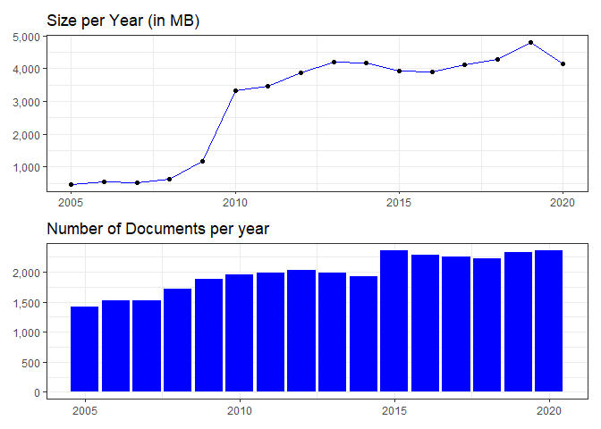

```r
.tmp <- tab_download %>%
  group_by(year) %>%
  summarise(size = sum(size), n = n(), .groups = "drop")


.geom_size <- .tmp %>%
  ggplot(aes(x = year, y = size)) +
  geom_line(color = "blue") +
  geom_point() +
  labs(x = NULL, y = NULL) +
  scale_y_continuous(labels = scales::comma) +
  theme_bw() +
  ggtitle("Size per Year (in MB)")

.geom_n <- .tmp %>%
  ggplot(aes(x = year, y = n)) +
  geom_col(fill = "blue") +
  labs(x = NULL, y = NULL) +
  scale_y_continuous(labels = scales::comma) +
  theme_bw() +
  ggtitle("Number of Documents per year")

.geom_size / .geom_n
```

```r
tab_download_txt <- tab_download %>%
  filter(file_ext == "txt", desc == "Complete submission text file") %>%
  arrange(symbol, desc(year), desc(period_date)) %>%
  distinct(symbol, year, .keep_all = TRUE) %>%
  distinct(document, .keep_all = TRUE)

cat(paste0(
  "Docs: ", comma(nrow(tab_download_txt)), "\n",
  "Size: ", comma(sum(tab_download_txt$size)), " MB")
  )
```

```
## Docs: 1,327
## Size: 28,347 MB
```

```r
tab_download_htm <- tab_download %>%
  filter(startsWith(file_ext, "htm"), grepl("10-K", desc)) %>%
  arrange(symbol, desc(year), desc(period_date)) %>%
  distinct(symbol, year, .keep_all = TRUE) %>%
  distinct(document, .keep_all = TRUE)

cat(paste0(
  "Docs: ", comma(nrow(tab_download_htm)), "\n",
  "Size: ", comma(sum(tab_download_htm$size)), " MB")
  )
```

```
## Docs: 967
## Size: 3,728 MB
```

```r
tab_download_xxx <- tab_download %>%
  filter(startsWith(file_ext, "x")) %>%
  arrange(symbol, desc(year), desc(period_date)) %>%
  distinct(document, .keep_all = TRUE)

cat(paste0(
  "Docs: ", comma(nrow(tab_download_xxx)), "\n",
  "Size: ", comma(sum(tab_download_xxx$size)), " MB")
  )
```

```
## Docs: 6,049
## Size: 9,511 MB
```

## Download Documents

Again we use a custom function **download_edgar_files()** to download the documents.

```r
.dir_docs <- "2_output/01_get_edgar_data/documents/"
tab_xxx <- download_edgar_files(tab_download_xxx, .dir_docs, 10, 2)
tab_htm <- download_edgar_files(tab_download_htm, .dir_docs, 10, 2)
tab_txt <- download_edgar_files(tab_download_txt, .dir_docs, 10, 2)

tab_zip_files <- list_files_tab(.dir_docs, info = TRUE) %>%
  select(doc_id, file_ext, path, size) %>%
  mutate(size = size / 1e6)
```

```r
cat(paste0(
  "Docs: ", comma(nrow(tab_zip_files)), "\n",
  "Size: ", comma(sum(tab_zip_files$size)), " MB")
  )
```

```
## Docs: 3,298
## Size: 3,768 MB
```

## Save Files

```r
write_rds(tab_download_htm, "2_output/01_get_edgar_data/htm_download.rds")
write_rds(tab_download_txt, "2_output/01_get_edgar_data/txt_download.rds")
write_rds(tab_download_xxx, "2_output/01_get_edgar_data/xxx_download.rds")
```

# Own Function Calls

```r
lsf.str()
```

```
## create_dirs : function (.dirs)
## downlad_ar : function (.url, .dir)
## download_edgar_files : function (.tab, .dir, .retry = 5, .sleep = 1)
## get_company_table : function (.url)
## get_f500 : function ()
## get_infos : function (.path)
## list_files_tab : function (dirs, reg = "*", id = "doc_id", rec = FALSE, info = FALSE)
## map_company_filings : function (.tickers, .ownership = FALSE, .type = "", .before = "", .count = 100, .page = 1, .progress = TRUE, .sleep = 0,
##     .retry = 5)
## map_filing_details : function (.id, .hrefs, .progress = TRUE, .sleep = 0, .retry = 5)
## remove_html_tags : function (.string, rm_linebreaks = TRUE)
## safe_get_company_table : function (...)
## standardize_name : function (.name)
```